# Laboratorio 4 en R: Inferencia

Kerry Loaiza Marín

[figure not shown]

En este laboratorio se utilizarán los siguientes archivos:

Download Lab4.csv Download LONDON.dat

# 1 Cálculo de probabilidades y percentiles de distribuciones normales

La función **pnorm** permite calcular la probabilidad acumulada de que una variable con distribución normal estándar caiga a la izquierda de un valor determinado $z$. Esto se representa de manera gráfica así:

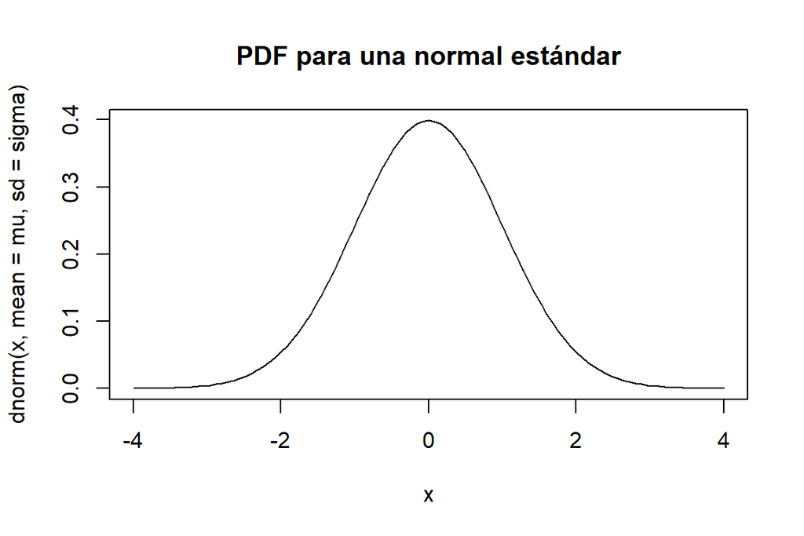

```r
#Primero una normal en general
mu    <- 0
sigma <- 1 # standard deviation

curve(dnorm(x, mean = mu, sd = sigma), # notice the 3rd argument is the sd
      from = -4, to = 4,
      main = "PDF para una normal estándar")
```

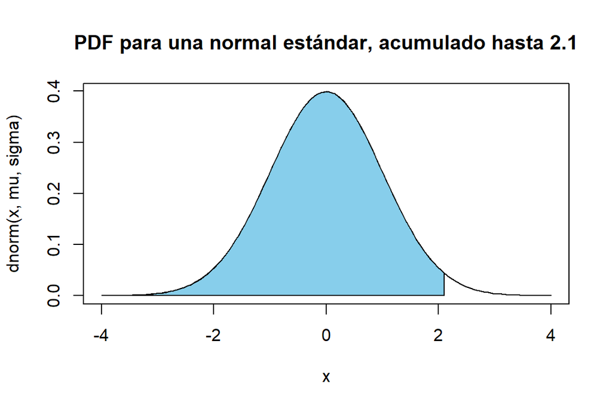

```r
#Segundo sombreamos la probabilidad acumulada que tendría un valor en la distribución normal estándar, en este caso usamos 2.1

sigma <- 1
mu <- 0
lower.x <- mu-4*sigma
upper.x <- 2.1
step <- (upper.x - lower.x) / 100
bounds <- c(mu-4*sigma, mu+4*sigma)
cord.x <- c(lower.x,seq(lower.x,upper.x,step),upper.x)
cord.y <- c(0,dnorm(seq(lower.x,upper.x,step),mu,sigma),0)
curve(dnorm(x,mu,sigma),xlim=bounds,
      main = "PDF para una normal estándar, acumulado hasta 2.1")
polygon(cord.x,cord.y,col='skyblue')
```

Muchas distribuciones de probabilidad estándar tienen funciones en R para calcular:

1. La función de densidad de probabilidad en las continuas o la función de masa de probabilidad en las discretas (d).
2. La función de distribución acumulada (p).
3. La función de cuantil (q).
4. Tiradas aleatorias (r).

Donde cada letra indica la función a utilizar. Algunas de las distribuciones disponibles son:

1. Binomial: dbinom.
2. Poisson: dpois.
3. Uniforme: dunif.
4. Normal: dnorm.
5. T de student: dt.
6. F: df.

**Ejercicio 1:** Compute la probabilidad de obtener un número entre 1 y 1/3 en una distribución normal estándar.

```r
#Para calcular la probabilidad se restan sus probabilidades acumuladas

pnorm(1)-pnorm(1/3)
```

```
## [1] 0.2107861
```

**Ejercicio 2:** Realice un dibujo donde se represente con un área sombreada la probabilidad calculada anteriormente.

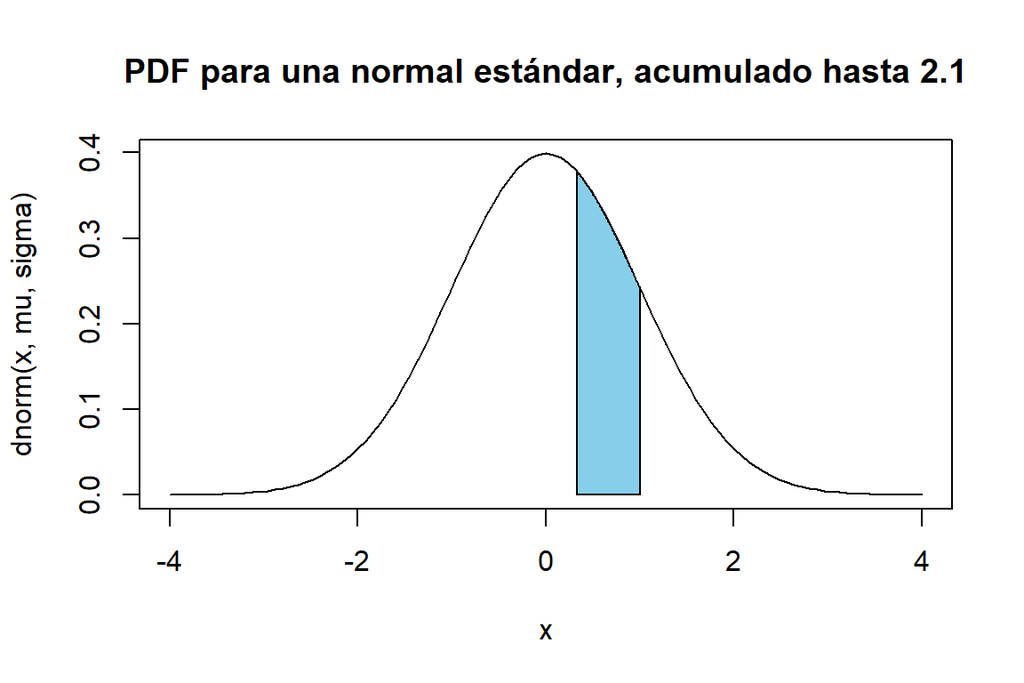

```r
sigma <- 1
mu <- 0
lower.x <- 1/3
upper.x <- 1
step <- (upper.x - lower.x) / 100
bounds <- c(mu-4*sigma, mu+4*sigma)
cord.x <- c(lower.x,seq(lower.x,upper.x,step),upper.x)
cord.y <- c(0,dnorm(seq(lower.x,upper.x,step),mu,sigma),0)
curve(dnorm(x,mu,sigma),xlim=bounds,
      main = "PDF para una normal estándar, acumulado hasta 2.1")
polygon(cord.x,cord.y,col='skyblue')
```

Ahora trabajaremos con los percentiles. La idea es obtener el percentil $z$ de una distribución de densidad normal estándar, tal que $P(Z<z)=p$. Por ejemplo, el valor del percentil número 10 de una distribución de densidad normal estándar sería de -1.28. Note que la función pnorm toma el valor $z$ y brinda la probabilidad, mientras la función qnorm toma la probabilidad y brinda el valor $z$. Es decir, la función pnorm es la inversa de qnorm (aplica igual para las otras distribuciones).

```r
qnorm(0.10)
```

```
## [1] -1.281552
```

# 2 Intervalos de los parámetros estimados

Para construir intervalos de confianza de los parámetros estimados de una regresión, se pueden utilizar las estimaciones puntuales de dichos parámetros y las funciones estadísticas de R. En este caso, será de gran utilidad la función para obtener el valor del percentil deseado que se mencionó en la sección anterior. Puesto que en muchas ocasiones se trabajará con distribuciones t, el comando para obtener el valor crítico t de una variable aleatoria con v grados de libertad cuya densidad de probabilidad acumulada sea p es el siguiente: qt(p,v). Esto es,

$P[t_{v}\leq t_{crítico}]=p$

Recuerde que el intervalo de confianza se puede expresar como:

$Prob[t_{cal}-t^{v}_{\alpha/2}\times se(t_{cal}) \leq t_{v} \leq t_{cal}+t^{v}_{\alpha/2}\times se(t_{cal})]$

Así que, para para crear un intervalo de confianza, se necesitan básicamente tres elementos: la estimación puntual del coeficiente o t calculado ($t_{cal}$), su error estándar ($se(t_{cal})$) y el valor crítico t ya mencionado ($t^{v}_{\alpha/2}$) al nivel de significancia respectivo ($\alpha$) y con los grados de libertad debidos ($v$).

**Recuerde:** En R, la función **confit** ya brinda los intervalos de confianza para los estimadores de los parámetros.

**Ejercicio 3:** Importe el archivo “Lab4.csv”, donde podrá encontrar dos series, x (ingreso total) e y (gasto en comida). Genere una ecuación donde y sea explicado por una constate y por x. Luego extraiga los coeficientes estimados y construya de forma manual sus intervalos de confianza. Compárelos con los resultados de la función **confit**. **Recuerde** que debe utilizar la distribución *t-student*. Use 38 grados de libertad (¿Por qué?) y una significancia del 5%.

```r
datos <- read.csv("Lab4.csv", header = TRUE, sep = ";")

modelo_1<-lm(Y ~ X, data = datos)

coeficientes_modelo_1 <- coef(modelo_1)

se_coeficientes_modelo_1 <- sqrt(diag(vcov(modelo_1)))

interv_conf_coef1_modelo_1 <- as.data.frame(matrix(NA, nrow = 2, ncol = 2))

names(interv_conf_coef1_modelo_1)<-c("Alto", "Bajo")
rownames(interv_conf_coef1_modelo_1)<-c("Beta_1", "Beta_2")

interv_conf_coef1_modelo_1[1,1] <- coeficientes_modelo_1[1] + qt(0.975,38)*se_coeficientes_modelo_1[1]

interv_conf_coef1_modelo_1[1,2] <- coeficientes_modelo_1[1] - qt(0.975,38)*se_coeficientes_modelo_1[1]

interv_conf_coef1_modelo_1[2,1] <- coeficientes_modelo_1[2] + qt(0.975,38)*se_coeficientes_modelo_1[2]

interv_conf_coef1_modelo_1[2,2] <- coeficientes_modelo_1[2] - qt(0.975,38)*se_coeficientes_modelo_1[2]

coeficientes_modelo_1
```

```
## (Intercept)           X
##  40.7675565   0.1282886
```

```r
se_coeficientes_modelo_1
```

```
## (Intercept)           X
## 22.13865442  0.03053925
```

```r
summary(modelo_1)
```

```
##
## Call:
## lm(formula = Y ~ X, data = datos)
##
## Residuals:
##     Min      1Q  Median      3Q     Max
## -71.753 -19.666  -5.969  17.752  80.140
##
## Coefficients:
##             Estimate Std. Error t value Pr(>|t|)
## (Intercept) 40.76756   22.13865   1.841 0.073369 .
## X            0.12829    0.03054   4.201 0.000155 ***
## ---
## Signif. codes:  0 '***' 0.001 '**' 0.01 '*' 0.05 '.' 0.1 ' ' 1
##
## Residual standard error: 37.81 on 38 degrees of freedom
##   (3 observations deleted due to missingness)
## Multiple R-squared:  0.3171, Adjusted R-squared:  0.2991
## F-statistic: 17.65 on 1 and 38 DF,  p-value: 0.000155
```

```r
interv_conf_coef1_modelo_1
```

|  | Alto | Bajo |
| --- | --- | --- |
| Beta_1 | 85.5849193 | -4.0498063 |
| Beta_2 | 0.1901121 | 0.0664651 |

```r
confint(modelo_1)
```

```
##                   2.5 %     97.5 %
## (Intercept) -4.04980634 85.5849193
## X            0.06646511  0.1901121
```

**Ejercicio 4:** Genere los intervalos de confianza para cada uno de los coeficientes de la regresión del **Ejercicio 1** del **Laboratorio 3** (Con la base de datos London.dat, efectúe la siguiente regresión: wfood en una constante, age, nk, el logaritmo del gasto total (log(totexp)) y wtrans).

# 3 Pruebas t de dos y una cola

## 3.1 Prueba t de dos colas

**Ejercicio 5:** Suponga que quiere probar que, por cada $100 de ingreso, el gasto en comida crece $10, es decir, que $\beta_{1}=0.1$. Para comprobar si esto es cierto al 5% de significancia, es necesario efectuar una prueba de hipótesis de **dos colas** (¿cuáles serían las hipótesis?). Utilice la regresión anterior del **Ejercicio 3** para este ejercicio.

```r
#Ya tenemos el valor del coeficiente y su error estándar
#Los utilizamos para computar el estadístico t

estadistico_t <- (coeficientes_modelo_1[2]-0.1)/se_coeficientes_modelo_1[2]

#Obtenemos el valor absoluto del estadístico

abs_estadistico_t <- abs(estadistico_t)

#Calculamos la probabilidad de interés
#P[t(38) mayor o igual que |estadístico t|]

prob_estadistico_t <- 1 - pt(abs_estadistico_t,38)

#computamos el p-value de dos colas

p_value_estadistico_t <- 2*prob_estadistico_t

p_value_estadistico_t
```

```
##         X
## 0.3601345
```

En este caso el p-value es 0.36. ¿Cómo se interpreta este resultado en términos de la prueba de hipótesis?

Note que alternativamente se puede construir un intervalo de confianza del 95% centrado en el valor de Ho deseado, en este caso 0.1, y verificar que el $\beta_{1}$ esté dentro de ese intervalo.

Para determinar si el efecto de una variable explicativa es significativo estadísticamente, se puede efectuar una prueba muy similar a la anterior. La única diferencia es que en este caso se estaría probando si $\beta_{1}=0$. Note además, que cuando se corre una regresión, la salida de la función **summary** sobre el objeto que guarda los resultados muestra tanto el estadístico t como el p-value.

**Ejercicio 6:** Realice una prueba de significancia para $\beta_{0}$ y $\beta_{1}$ según la metodología anterior y verifique si sus resultados son iguales a los que muestra el software. Además construya el intervalo de confianza de $\beta_{1}$ centrado en 0.1 del Ejercicio 5 y verifique si el valor de $\beta_{1}$ se encuentra dentro del rango calculado.

## 3.2 Prueba de una cola

**Ejercicio 7:** Suponga que se quiere probar si $\beta_{1}=0.1$ contra la hipótesis alternativa $\beta_{1}>0.1$. En este caso la prueba es de una cola. El cálculo del estadístico $t$ es idéntico al caso de dos colas, sin embargo, tanto el p-value como el valor crítico son distintos. Utilice la estimación anterior para ejecutar esta prueba.

```r
#Ya tenemos el estadístico t, no es necesario su valor absoluto

#Calculamos el valor crítico de cola derecha

valor_crit_estadistico <- pt(0.95,38)

#Calculamos la probabilidad de interés, en este caso es igual al p-value (una alternativa es no restarlo a 1 y usar la opción de la función pt: lower.tail = FALSE)

prob_estadistico_t2 <- 1 - pt(estadistico_t,38)

prob_estadistico_t2
```

```
##         X
## 0.1800673
```

**Ejercicio 8:** Ahora ejecute a prueba de hipótesis $\beta_{1}=0.1$ contra la alternativa $\beta_{1} < 0.1$.

```r
#Ya tenemos el estadístico t, no es necesario su valor absoluto

#Calculamos el valor crítico de cola izquierda

valor_crit_estadistico <- pt(0.05,38)

#Calculamos la probabilidad de interés, en este caso es igual al p-value (note que no lo restamos a 1)

prob_estadistico_t2 <- pt(estadistico_t,38)
prob_estadistico_t2
```

```
##         X
## 0.8199327
```

Note que existen dos diferencias fundamentales entre la prueba de dos colas y la de una cola. La primera es que en el caso de una cola no se divide la significancia entre dos para obtener el valor crítico y la segunda es que no se está multiplicando por dos el p-value como en el caso de dos colas.

Aprender a efectuar pruebas a una cola es de suma importancia en el ámbito económico. Por ejemplo según la teoría, aumentos en el ingreso se traducirían a su vez en incrementos en el gasto. En estos casos, debería probarse la hipótesis nula $\beta_{1} = 0.1$ contra la alternativa $\beta_{1}>0.1$, es decir que la prueba correcta es de una cola.

# 4 Construcción de intervalos de pronóstico

Note que los datos utilizados hasta ahora poseen no 40 sino 43 observaciones para la variable $X$, mientras esas últimas 3 observaciones son valores ausentes en $Y$. La función **lm** utilizada para la estimación reconoce automáticamente esto y elimina esas observaciones de $X$ para la estimación.

Con los resultados de regresión lineal podemos hacer pronósticos fuera de muestra para esas 3 observaciones de $Y$. Vimos en el **Laboratorio 2** que la función **predict.lm** es útil para la predicción dentro de muestra. También la podemos utilizar para predicción fuera de muestra, con todo y los intervalos de confianza.

```r
prediccion_modelo_1<-predict.lm(object =  modelo_1, newdata = datos[c(41:43),], se.fit = TRUE, level = 0.95, interval = c("confidence"))

prediccion_modelo_1$fit
```

```
##         fit      lwr      upr
## 41 136.9840 124.4633 149.5047
## 42 143.3984 129.7530 157.0439
## 43 149.8129 134.4917 165.1341
```

Note que la función **predict.lm** posee dos opciones para el intervalo: “confidence” y “prediction”. Los intervalos de predicción reflejan la incertidumbre alrededor de las observaciones específicas, mientras que los intervalos de confianza reflejan la incertidumbre alrededor de los valores promedio predichos. Entonces, un intervalo con “prediction” va a ser, generalmente, mucho más amplio que un intervalo con “confidence” para el mismo valor.